# Imports:

```python
#NLTK libraries
import nltk #Natural Language Toolkit
import re #Regular Expressions
import string #String Library
from nltk.stem import WordNetLemmatizer #WordNetLemmatizer Library
from nltk import pos_tag #POS Tagging Library
from nltk.corpus import wordnet #WordNet Library
from wordcloud import WordCloud #WordCloud Library

#Pandas Libraries
import numpy as np # linear algebra
import pandas as pd # data processing, CSV file I/O (e.g. pd.read_csv)

#Metrics libraries
from sklearn import metrics #Metrics Library
from sklearn.metrics import classification_report, accuracy_score #Classification Report and Accuracy Score
from sklearn.model_selection import cross_val_score #Cross Validation Score

#Visualization libraries
import matplotlib.pyplot as plt #Matplotlib
from matplotlib import rcParams #Matplotlib
import seaborn as sns #Seaborn
from plotly import tools #Plotly
import plotly.graph_objs as go #Plotly
from plotly.offline import iplot #Plotly
import plotly.io as pio #Plotly
%matplotlib inline

# Model training Libraries
from sklearn.model_selection import train_test_split
from tensorflow.keras.models import Sequential
from tensorflow.keras.layers import Dense, Dropout, LSTM, Activation
from keras.layers import Dense, Embedding, LSTM, SpatialDropout1D,CuDNNLSTM
from keras.callbacks import EarlyStopping
from sklearn.metrics import confusion_matrix

# NLP libraries
from sklearn import preprocessing  #Preprocessing Library
from keras.preprocessing.text import Tokenizer
from keras_preprocessing.sequence import pad_sequences
import tensorflow as tf
from nltk.stem.porter import PorterStemmer #Porter Stemmer
from sklearn.base import BaseEstimator, TransformerMixin
from sklearn.pipeline import Pipeline


#Other miscellaneous libraries
import cufflinks as cf #Cufflinks
from collections import defaultdict #Default Dictionary
from collections import Counter #Counter

#Dataset reference:
#https://www.kaggle.com/datasets/kritanjalijain/amazon-reviews
# Author: Kritanjali Jain
```

Introduction to the Dataset:

This dataset consists of reviews from amazon on different products over the span of a 18 year period up to March 2013.

This dataset is a subset dataset consisting of a total of 1 800 000 records

The sentiment of each review has already been specified in the dataset

The sentiment for each review has been decided by taking the review score 1 and 2 as negative and 4 and 5 as positive

Review scores of 3 have been ignored to improve the models ability to distingush between positive and negative sentiment

```python
# Import the raw dataset using Pandas and create a dataframe with specified column names
data = pd.read_csv('amazon_reviews.csv')
```

The dataset consists of three columns:

Sentiment: 1 is negative and 2 is positive

Review Title: The review heading

Review text: The review body

Due to the large size of the dataset, I have decided to randomly select 540 000 observations and create a new csv file. The original dataset is on kaggle  
This decision is to reduce the run time of my model when testing and to satisfy the minimum record requirement for Task 1

```python
test_model_data = data.copy()#copy the data for the test model
```

Creates a copy of the data for the test model to ensure the models dont affect one another

```python
data.head()
```

|  | sentiment | review_title | review_text |
| --- | --- | --- | --- |
| 0 | 1 | Expensive Junk | This product consists of a piece of thin flexi... |
| 1 | 1 | Toast too dark | Even on the lowest setting, the toast is too d... |
| 2 | 2 | Excellent imagery...dumbed down story | I enjoyed this disc. The video is stunning. I ... |
| 3 | 1 | Are we pretending everyone is married? | The authors pretend that parents neither die n... |
| 4 | 1 | Not worth your time | Might as well just use a knife, this product h... |

We can see that the dataset has been imported correctly

Each record has been added to the correct corresponding column

```python
data.shape
```

```
(540000, 3)
```

The dataset consists of: 540 000 observations and 3 columns

```python
data.info()
```

```
<class 'pandas.core.frame.DataFrame'>
RangeIndex: 540000 entries, 0 to 539999
Data columns (total 3 columns):
 #   Column        Non-Null Count   Dtype
---  ------        --------------   -----
 0   sentiment     540000 non-null  int64
 1   review_title  539993 non-null  object
 2   review_text   540000 non-null  object
dtypes: int64(1), object(2)
memory usage: 12.4+ MB
```

The dataset consists of: Int (Sentiment) and two objects (review_title, review_text)

# Feature Engineering:

```python
# Check for null values
data.isnull().sum()
```

```
sentiment       0
review_title    7
review_text     0
dtype: int64
```

The dataset consists of 7 null values in the review_title column

```python
# Pipeline methods for cleaning the data and feature engineering

# Specified stop words to be removed from the data
# Certain words may change the meaning of the next word therefore the stop words are specified

stop_words= ['yourselves', 'between', 'whom', 'itself', 'is', "she's", 'up', 'herself', 'here', 'your', 'each',
             'we', 'he', 'my', "you've", 'having', 'in', 'both', 'for', 'themselves', 'are', 'them', 'other',
             'and', 'an', 'during', 'their', 'can', 'yourself', 'she', 'until', 'so', 'these', 'ours', 'above',
             'what', 'while', 'have', 're', 'more', 'only', "needn't", 'when', 'just', 'that', 'were', "don't",
             'very', 'should', 'any', 'y', 'isn', 'who',  'a', 'they', 'to', 'too', "should've", 'has', 'before',
             'into', 'yours', "it's", 'do', 'against', 'on',  'now', 'her', 've', 'd', 'by', 'am', 'from',
             'about', 'further', "that'll", "you'd", 'you', 'as', 'how', 'been', 'the', 'or', 'doing', 'such',
             'his', 'himself', 'ourselves',  'was', 'through', 'out', 'below', 'own', 'myself', 'theirs',
             'me', 'why', 'once',  'him', 'than', 'be', 'most', "you'll", 'same', 'some', 'with', 'few', 'it',
             'at', 'after', 'its', 'which', 'there','our', 'this', 'hers', 'being', 'did', 'of', 'had', 'under',
             'over','again', 'where', 'those', 'then', "you're", 'i', 'because', 'does', 'all']

review_features = ['review_text']

# Function to remove null values
class ClearNulls(BaseEstimator, TransformerMixin):
    def fit(self, X, y=None):
        return self

    def transform(self, X):
        #drop missing reviews
        X = X.dropna()
        return X

# Function to combine review title and review text
class CombineReviewSum(BaseEstimator, TransformerMixin):
    def fit(self, X, y=None):
        return self

    def transform(self, X):
        # Combine the review_title and review_test
        X['reviews'] = X['review_title'].str.cat(X['review_text'], sep=' ')

        return X.drop(['review_title', 'review_text'], axis=1)

# Function to remove punctuation
class RemovePunctuation(BaseEstimator, TransformerMixin):
    def fit(self, X, y=None):
        return self

    def transform(self, X):
        # remove punctuation
        def clean_review(text):
            text = str(text).lower()
            text = re.sub('\[.*?\]', '', text)
            text = re.sub('https?://\S+|www\.\S+', '', text)
            text = re.sub('<.*?>+', '', text)
            text = re.sub('[%s]' % re.escape(string.punctuation), '', text)
            text = re.sub('\n', '', text)
            text = re.sub('\w*\d\w*', '', text)
            return text

        X['reviews'] = X['reviews'].apply(lambda x: clean_review(x))
        return X

# Function to remove stop words
class StopWords (BaseEstimator, TransformerMixin):
    def fit(self, X, y=None):
        return self

    def transform(self, X):
        # remove stop words
        X['reviews'] = X['reviews'].apply(lambda x: ' '.join([word for word in x.split() if word not in (stop_words)]))
        return X

#Function to one-hot encode the data
class LabelEncoder(BaseEstimator, TransformerMixin):
    def fit(self, X, y=None):
        return self

    def transform(self, X):
        # label encode the sentiment column
        le = preprocessing.LabelEncoder()
        X['sentiment']= le.fit_transform(X['sentiment'])
        return X
```

The pipleline used for cleaning performs the following tasks:

Removes all nulls

Combine review_title and review_text columns

Removes all punctuation

Removes specified stop_words

*Please Note:*  
Due to the nature of the dataset being amazon reviews, it is important to include stop words like "not" because it can change the meaning or interpretation of the review.  
This is the reason for specifying what stop words must be removed from the text.

During testing I created the model only using the review_text column, this resulted in an accuracy of 85%.  
To increase the models accuracy and perfomance, I have combined the review_title and review_text columns.  
This resulted in an increase of 7-8% in the models performance from 85% to 93%

```python
# Calls the pipeline methods
pipe = Pipeline([
    ('clearnull', ClearNulls()),
    ('combinereviewsum', CombineReviewSum()),
    ('removepunctuation', RemovePunctuation()),
    ('stopword', StopWords()),
    ('labelencoder', LabelEncoder())
])

# Apply the pipeline to the dataframe
data = pipe.fit_transform(data)
data.head()
```

|  | sentiment | reviews |
| --- | --- | --- |
| 0 | 0 | expensive junk product consists piece thin fle... |
| 1 | 0 | toast dark even lowest setting toast dark liki... |
| 2 | 1 | excellent imagerydumbed down story enjoyed dis... |
| 3 | 0 | pretending everyone married authors pretend pa... |
| 4 | 0 | not worth time might well use knife product ho... |

The dataset has been cleaned and review_title and review_text has been combined into column reviews

```python
# Check for null values
data.isnull().sum()
```

```
sentiment    0
reviews      0
dtype: int64
```

There are no null values after cleaning and combining the review_title and review_text columns

```python
# Create a copy of dataset only consisting of the reviews column
stem_dataset = data.copy()
stem_dataset = stem_dataset[['reviews']].reset_index(drop=True)
stem_dataset.head()
```

|  | reviews |
| --- | --- |
| 0 | expensive junk product consists piece thin fle... |
| 1 | toast dark even lowest setting toast dark liki... |
| 2 | excellent imagerydumbed down story enjoyed dis... |
| 3 | pretending everyone married authors pretend pa... |
| 4 | not worth time might well use knife product ho... |

A new dataset is created with only the Reviews column in preparation for lemmatization

# Lemmatization:

```python
# Applying Lemmmatizer to remove tenses from texts.
lemmatizer = WordNetLemmatizer()

def preprocess_text(text):
    text = re.sub(r"won\'t", "will not", text)
    text = re.sub(r"can\'t", "can not", text)
    text = re.sub('[^a-zA-Z0-9]',' ',text)
    text = [lemmatizer.lemmatize(word) for word in text.split() if not word in set(stop_words)]
    text = ' '.join(text)
    return text
```

```python
data.reviews[0]
```

```
'expensive junk product consists piece thin flexible insulating material adhesive backed velcro white electrical instructions three pictures little velcro crumpled received stronger adhesive tried disengage velcro pieces came off paint white electrical tape horrible cheap narrow fell off less price …
```

```python
data["reviews"] = data["reviews"].apply(preprocess_text)
```

The dataset has been lemmatized using the WordNetLemmatizer

```python
data.reviews[0]
```

```
'expensive junk product consists piece thin flexible insulating material adhesive backed velcro white electrical instruction three picture little velcro crumpled received stronger adhesive tried disengage velcro piece came off paint white electrical tape horrible cheap narrow fell off le price ripof…
```

Here we can see a record after being lemmatized which confirms the lemmatization was successful

# Visualizing the Data:

```python
# counts the number of positive and negative reviews
data.sentiment.value_counts()
```

```
1    270052
0    269941
Name: sentiment, dtype: int64
```

The dataset consists of a balanced number of positive and negative reviews, therefore we dont need to use SMOTE to balance the sample.

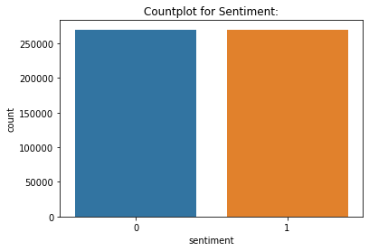

```python
# creates a count plot for the number of positive and negative reviews
sns.countplot(data.sentiment)
plt.title("Countplot for Sentiment:")
plt.rcParams['figure.facecolor'] = 'white'
```

The Countplot illustrates:

There is no significant different between the number of positive and negative reviews

Therefore our dataset is balanced and appropriate to be used in the model

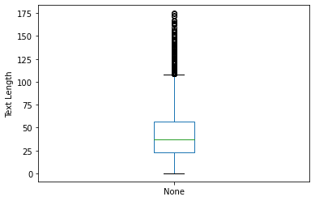

```python
# creates a box and whiskers for review length of each review
text_length = pd.Series([len(review.split()) for review in data["reviews"]])
text_length.plot(kind="box")
plt.ylabel("Text Length")
plt.rcParams['figure.facecolor'] = 'white'
```

The box & whiskers plot illustrates:

The outliers may decrease the models accuracy

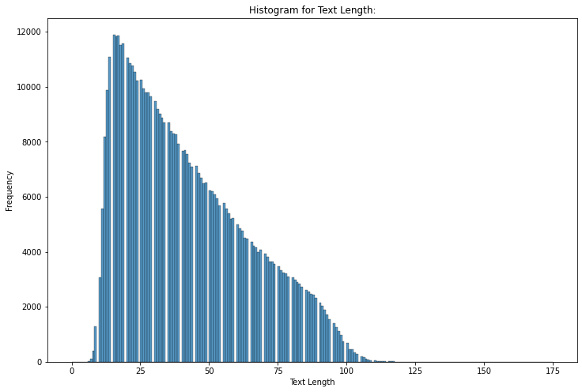

```python
plt.figure(figsize=(12,8))
sns.histplot(text_length,palette="deep")
plt.title("Histogram for Text Length:")
plt.xlabel("Text Length")
plt.ylabel("Frequency")
plt.rcParams['figure.facecolor'] = 'white'
```

The histogram plot illustrates:

This indicates that the outliers are few and should not affect the accuracy of the model

## WordCloud

```python
#Filtering data into seperate dataframes
positive_review = data[data["sentiment"]==1].dropna()
negative_review = data[data["sentiment"]==0].dropna()
```

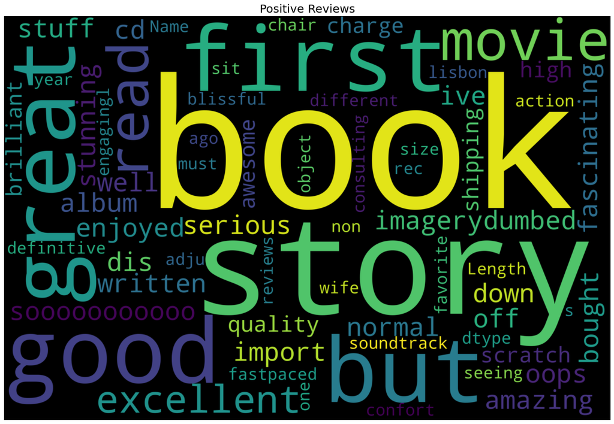

```python
# method generates a wordcloud for positive reviews
text = positive_review["reviews"]
wordcloud = WordCloud(
    width = 3000,
    height = 2000,
    stopwords = stop_words).generate(str(text))

fig = plt.figure(figsize = (16, 10))
plt.imshow(wordcloud, interpolation = 'bilinear')
plt.axis('off')
plt.title('Positive Reviews', fontsize = 20)
plt.rcParams['figure.facecolor'] = 'white'
plt.tight_layout(pad=0)
plt.show()
```

The positive Wordcloud illustrates:

Majority of positive reviews consist of words like: good, great, book, story, first

From this we can already see a positive sentiment but certain words are missing leading like book

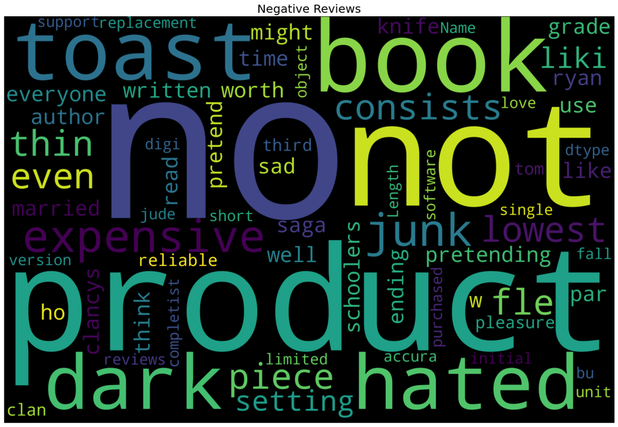

```python
# method generates a wordcloud for negative reviews
text = negative_review["reviews"]
wordcloud = WordCloud(
    width = 3000,
    height = 2000,
    background_color = 'black',
    stopwords = stop_words).generate(str(text))

fig = plt.figure(figsize = (16, 10))
plt.imshow(wordcloud, interpolation = 'bilinear')
plt.axis('off')
plt.title('Negative Reviews', fontsize = 20)
plt.rcParams['figure.facecolor'] = 'white'
plt.tight_layout(pad=0)
plt.show()
```

The negative Wordcloud illustrates:

Majority of negative reviews consist of words like: product, not, no, hated, dark, book

From this we can already see a negative sentiment but certain words are missing leading like book or product

## N-Gram:

From the WordCloud, we gain an understanding of what type of words are mainly used in each type of review.  
The issue is that certain words are common between both types of reviews like product or book.  
Therefore to gain a better visualization of the dataset, an N-Gram can be used to display common phrases used in the reviews.

```python
# allows plotyly graphs to be illustrated in the notebook
pio.renderers.default = "notebook_connected"
```

```python
## custom function for ngram generation
def generate_ngrams(text, n_gram = 1):
    token = [token for token in text.lower().split(" ") if token != "" if token not in stop_words]
    ngrams = zip(*[token[i:] for i in range(n_gram)])
    return [" ".join(ngram) for ngram in ngrams]
```

```python
# custom function for horizontal bar chart
def horizontal_bar_chart(df, color):
    trace = go.Bar(
        y =df["word"].values[::-1],
        x = df["wordcount"].values[::-1],
        showlegend = False,
        orientation = 'h',
        marker = dict(
            color = color,
        ),
    )
    return trace
```

```python
## Get the bar chart from positive reviews
freq_dict = defaultdict(int)
for sent in positive_review["reviews"]:
    for word in generate_ngrams(sent, 3):
        freq_dict[word] += 1
fd_sorted = pd.DataFrame(sorted(freq_dict.items(), key=lambda x: x[1])[::-1])
fd_sorted.columns = ["word", "wordcount"]
trace0 = horizontal_bar_chart(fd_sorted.head(20), 'blue')


## Get the bar chart from negative reviews
freq_dict = defaultdict(int)
for sent in negative_review["reviews"]:
    for word in generate_ngrams(sent, 3):
        freq_dict[word] += 1
fd_sorted = pd.DataFrame(sorted(freq_dict.items(), key=lambda x: x[1])[::-1])
fd_sorted.columns = ["word", "wordcount"]
trace2 = horizontal_bar_chart(fd_sorted.head(20), 'yellow')
```

```python
# Creating two subplots
fig = tools.make_subplots(rows=2, cols=1, vertical_spacing = 0.04, subplot_titles=["Frequent words of positive reviews","Frequent words of negative reviews"])
fig.append_trace(trace0, 1, 1)
fig.append_trace(trace2, 2, 1)
fig['layout'].update(height=1200, width=900, paper_bgcolor='rgb(233,233,233)', title="Word Count Plots")
iplot(fig, filename='word-plots')
```

[interactive chart not shown]

The N-gram illustrates:

The most common three word phrases that are used for positive and negative reviews

The most common phrases used for positive reviews are: highly recommend book, would highly recommend, couldnt put down

The most common phrases used for negative reviews are: dont waste money, would not recommend, dont waste time

Something interesting to note:

The distribution of phrases for positive reviews is widely spread

The distribution of phrases for negative reviews is narrowly spread

# Building the Model:

```python
# creates numpy array to store the reviews
X = np.array(data['reviews'])
```

```python
# creates a numpy array to store the sentiment
y = np.array(data['sentiment'])
```

```python
# Tokenizes the reviews
x_flatten = X.flatten()

max_fatures = 2000
tokenizer = Tokenizer(num_words=max_fatures, split=' ')
tokenizer.fit_on_texts(x_flatten)
```

```python
# converts the reviews to sequences
X = tokenizer.texts_to_sequences(x_flatten)
X = pad_sequences(X, maxlen = 75)
```

```python
# Splits the data into training and testing dataframes
x_train, x_test, y_train, y_test = train_test_split(X, y, test_size=0.2, random_state=42)
```

```python
# Long Short Term Memory Neural Network
embed_dim = 128 # Hypertuned Embedding Dimension
lstm_out = 196 # Hypertuned LSTM Output Dimension

vocab_size = len(tokenizer.word_index) + 1

model = Sequential() # Initializes the model
model.add(Embedding(max_fatures,embed_dim,input_length = X.shape[1])) # Adds the embedding layer
model.add(SpatialDropout1D(0.4))# Adds the Spatial Dropout Layer
model.add(LSTM(lstm_out, dropout=0.2, recurrent_dropout=0)) # Adds the LSTM Layer
model.add(Dense(2,activation='softmax')) # Adds the Dense Layer
model.compile(loss = 'sparse_categorical_crossentropy', optimizer='adam',metrics = ['accuracy']) # Compiles the model
print(model.summary()) # Prints the model summary
```

```
Model: "sequential"
_________________________________________________________________
 Layer (type)                Output Shape              Param #
=================================================================
 embedding (Embedding)       (None, 75, 128)           256000

 spatial_dropout1d (SpatialD  (None, 75, 128)          0
 ropout1D)

 lstm (LSTM)                 (None, 196)               254800

 dense (Dense)               (None, 2)                 394

=================================================================
Total params: 511,194
Trainable params: 511,194
Non-trainable params: 0
_________________________________________________________________
None
```

The model has been compiled using the sparse_categorical_crossentropy loss and activation function softmax.

These two methods are the most appropriate for the type of input data I am providing to the model.

The optimizer selected is adam and the metric is accuracy. These two methods provide the best accuracy for NLP data while still keeping the runtime manageable.

The tuned hyperparameters are: embed_dim = 128, lstm_out = 196 and dropout = 0.2

The max features has been specified to 2000 by the tokenizer, this will ensure that the model doesnt add unneccessary weighting to meaningless words

## Early Stopping:

```python
# Creates early stop variable for the model
early_stop = EarlyStopping(monitor="val_loss",patience=5,verbose=True)
```

This is a method that allows you to specify a large amount of training Epochs and stop training once the model performance stops improving on a validation set

This method is used to combat over and underfitting

```python
# fits the model to the training data
batch_size = 64
history = model.fit(x_train, y_train, epochs = 15, batch_size=batch_size, verbose = 1, validation_data=(x_test, y_test),callbacks=[early_stop])
```

```
Epoch 10: early stopping
```

The model performed well with a training accuracy of 93% and a validation accuracy of 92%

# Evaluating the model:

```python
# Evaluates the model using a validation set
validation_size = 1500

X_validate = x_test[-validation_size:]
Y_validate = y_test[-validation_size:]
X_test = x_test[:-validation_size]
Y_test = y_test[:-validation_size]
score,acc = model.evaluate(X_test, Y_test, verbose = 2, batch_size = batch_size)
print("score: %.2f" % (score))
print("acc: %.2f" % (acc))
```

```
1665/1665 - 5s - loss: 0.2008 - accuracy: 0.9221 - 5s/epoch - 3ms/step
score: 0.20
acc: 0.92
```

The model performed well after evaluation using the test data.  
The model had an accuracy of 92% and a loss of 0.20

```python
# evaluate the model
_, train_acc = model.evaluate(x_train, y_train, verbose=2)
_, test_acc = model.evaluate(x_test, y_test, verbose=2)
print('Train: %.3f, Test: %.4f' % (train_acc, test_acc))
```

```
13500/13500 - 34s - loss: 0.1292 - accuracy: 0.9516 - 34s/epoch - 2ms/step
3375/3375 - 8s - loss: 0.2009 - accuracy: 0.9220 - 8s/epoch - 2ms/step
Train: 0.952, Test: 0.9220
```

The comparison above shows that testing the model against the training data will result in inaccurate results!

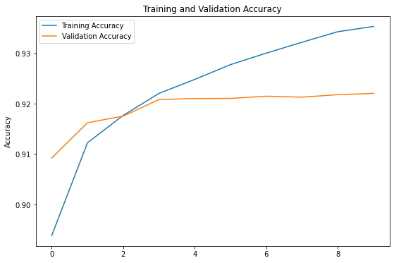

```python
# Creates a line graph to display accuracy of the model per epoch
acc = history.history["accuracy"]
loss = history.history["loss"]

val_acc = history.history["val_accuracy"]
val_loss = history.history["val_loss"]

plt.figure(figsize=(9,6))
plt.plot(acc,label="Training Accuracy")
plt.plot(val_acc,label="Validation Accuracy")
plt.legend()
plt.ylabel("Accuracy")
plt.title("Training and Validation Accuracy")
plt.rcParams['figure.facecolor'] = 'white'
```

The line graph illustrates:

The training accuracy consistenly increase with each Epoch

The validation accuracy increases with each Epoch and slowly levels out which indicates to the model it should early stop to avoid overfitting

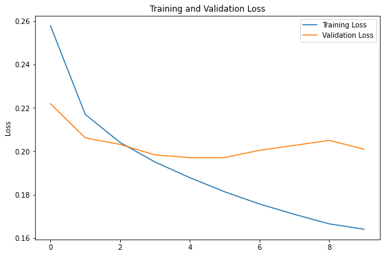

```python
# Creates a line graph to display loss of the model per epoch
plt.figure(figsize=(9,6))
plt.plot(loss,label="Training Loss")
plt.plot(val_loss, label="Validation Loss")
plt.legend()
plt.ylabel("Loss")
plt.title("Training and Validation Loss")
plt.rcParams['figure.facecolor'] = 'white'
```

The line graph illustrates:

The training loss consistenly decreases with each Epoch

```python
# predict probabilities for test set
pred_probs = model.predict(x_test, verbose=0)
print(pred_probs)

# predict crisp classes for test set
predict_x = (model.predict(x_test))
pred_classes = np.argmax(predict_x,axis=1)
print(pred_classes)

# reduce to 1d array
pred_probs = pred_probs[:, 0]
#pred_classes = pred_classes[:, 0]
```

```
[[9.9989402e-01 1.0598396e-04]
 [9.9798524e-01 2.0147045e-03]
 [9.9913847e-01 8.6154568e-04]
 ...
 [8.4250766e-01 1.5749227e-01]
 [6.8180852e-02 9.3181920e-01]
 [7.8526791e-03 9.9214739e-01]]
[0 0 0 ... 0 1 1]
```

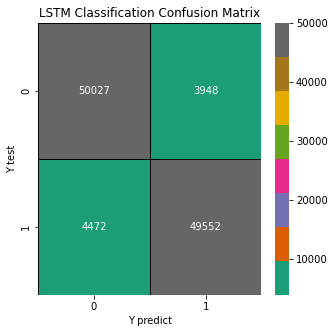

```python
# confusion matrix method
lstm_val = confusion_matrix(y_test, pred_classes)
f, ax = plt.subplots(figsize=(5,5))
sns.heatmap(lstm_val, annot=True, linewidth=0.7, linecolor='black', fmt='g', ax=ax, cmap="Dark2")
plt.title('LSTM Classification Confusion Matrix')
plt.xlabel('Y predict')
plt.ylabel('Y test')
plt.rcParams['figure.facecolor'] = 'white'
plt.show()
```

The confusion Matrix illustrates:

The model performed well and majority of the time made correct predictions

```python
print(classification_report(y_test, pred_classes))
```

```
              precision    recall  f1-score   support

           0       0.92      0.93      0.92     53975
           1       0.93      0.92      0.92     54024

    accuracy                           0.92    107999
   macro avg       0.92      0.92      0.92    107999
weighted avg       0.92      0.92      0.92    107999
```

# Prediction from Dataset:

```python
# Creates dataframe to store the input
sentiment1 = 0
review_title1 = ""
review_text1 = test_model_data.review_text[0] # calls negative review

# Add text to new dataframe
user_input_data1 = pd.DataFrame({"sentiment":[sentiment1],"review_title":[review_title1],"review_text":[review_text1]})
user_input_data1
```

|  | sentiment | review_title | review_text |
| --- | --- | --- | --- |
| 0 | 0 |  | This product consists of a piece of thin flexi... |

```python
# cleans the dataframe
user_cleaned_text1 = pipe.fit_transform(user_input_data1)
user_cleaned_text1.reviews
```

```
0    product consists piece thin flexible insulatin...
Name: reviews, dtype: object
```

```python
user_cleaned_text1["reviews"] = user_cleaned_text1["reviews"].apply(preprocess_text)
```

```python
X1 = np.array(user_cleaned_text1['reviews'])
X1 = tokenizer.texts_to_sequences(X1)
X1 = pad_sequences(X1, maxlen = 75)
```

```python
# Predicts the sentiment of the review and returns the predicted sentiment
user_input_pred1 = model.predict(X1)
print(user_input_pred1)
print(np.argmax(user_input_pred1))
sentiment_labels = ['negative', 'positive']
print( "Sentiment:" , np.argmax(user_input_pred1), " or ",sentiment_labels[np.argmax(user_input_pred1)])
```

```
[[0.9985159  0.00148404]]
0
Sentiment: 0  or  negative
```

## Prediction using User Input:

```python
# Creates dataframe to store the input
sentiment2 = 1
review_title2 = ""
review_text2 = "This is good product and I would highly recommend buying it." # calls positive review

# Add text to new dataframe
user_input_data2 = pd.DataFrame({"sentiment":[sentiment2],"review_title":[review_title2],"review_text":[review_text2]})
user_input_data2
```

|  | sentiment | review_title | review_text |
| --- | --- | --- | --- |
| 0 | 1 |  | This is good product and I would highly recomm... |

```python
# cleans the dataframe
user_cleaned_text2 = pipe.fit_transform(user_input_data2)
user_cleaned_text2.reviews
```

```
0    good product would highly recommend buying
Name: reviews, dtype: object
```

```python
user_cleaned_text2["reviews"] = user_cleaned_text2["reviews"].apply(preprocess_text)
```

```python
# Tokenizes the reviews, fits text and adds padding to the reviews
X2 = np.array(user_cleaned_text2['reviews'])
X2 = tokenizer.texts_to_sequences(X2)
X2 = pad_sequences(X2, maxlen = 75)
```

```python
# Predicts the sentiment of the review and returns the predicted sentiment
user_input_pred2 = model.predict(X2)
print(user_input_pred2)
print(np.argmax(user_input_pred2))
sentiment_labels2 = ['negative', 'positive']
print( "Sentiment:" , np.argmax(user_input_pred2), " or ",sentiment_labels2[np.argmax(user_input_pred2)])
```

```
[[0.00702062 0.99297935]]
1
Sentiment: 1  or  positive
```

The model was successfully able to predict the sentiment of the user inputted review without using review title

# Prediction Application(GUI):

*Please Note:*  
I have commented out the GUI application otherwise it will stop the whole notebook from fully runnining.  
*Please uncomment the GUI application code below if you want to use it*

```python
'''
from tkinter import *
class App(object):
    def __init__(self, window):

        lbl = Label(
            window,
            text="Please Enter a Review below:",
            fg="black",
            font=("Arial", 16),
        )
        lbl.place(x=60, y=10)

        # Text box
        self.txtfld1 = Entry(window, bd = 5, font=("Arial", 8))
        self.txtfld1.place(x=75, y=50,height=60, width=250)

        # Button
        self.btn = Button(
            window, text="Predict", fg="green", command=self.MyButtonClicked
        )
        self.btn.place(x=180, y=120)

    def MyButtonClicked(self):
        user_sentiment = 0
        user_input_review_title = ""
        user_input_review_text = self.txtfld1.get()

        # Add text to new dataframe
        user_input_df = pd.DataFrame({"sentiment":[user_sentiment],"review_title":[user_input_review_title],"review_text":[user_input_review_text]})

        # call cleaning pipeline
        user_input_cleaned_text = pipe.fit_transform(user_input_df)
        # Tokenizes the reviews, fits text and adds padding to the reviews
        X2 = np.array(user_input_cleaned_text['reviews'])
        X2 = tokenizer.texts_to_sequences(X2)
        X2 = pad_sequences(X2, maxlen = 75)

        # Predicts the sentiment of the review and returns the predicted sentiment
        user_input_prediction = model.predict(X2)
        temp_result = np.argmax(user_input_prediction)

        print("Button clicked")
        print(temp_result)

        if (temp_result) == 0:
            print("This was a negative review")
            lbl = Label(
            window,
            text="This was a negative review",
            fg="black",
            font=("Arial", 12),
            )
            lbl.place(x=130, y=150)
        else:
            print("This was a positive review")
            lbl = Label(
            window,
            text="This was a positive review",
            fg="black",
            font=("Arial", 12),
            )
            lbl.place(x=130, y=150)


if __name__ == "__main__":
    window = Tk()
    app = App(window)
    window.title("Review Sentiment Prediction Application")
    window.geometry("400x200+600+150")
    mainloop()

'''
```

[output not shown]

# Test model with Untuned Hyperparameters:

```python
# create new dataframe with only sentiment and reviews
test_review_data = test_model_data[['sentiment','review_text']]
test_review_data
```

|  | sentiment | review_text |
| --- | --- | --- |
| 0 | 1 | This product consists of a piece of thin flexi... |
| 1 | 1 | Even on the lowest setting, the toast is too d... |
| 2 | 2 | I enjoyed this disc. The video is stunning. I ... |
| 3 | 1 | The authors pretend that parents neither die n... |
| 4 | 1 | Might as well just use a knife, this product h... |
| ... | ... | ... |
| 539995 | 2 | After seeing the movie "Lisbon Story", we had ... |
| 539996 | 1 | Hated this book. Just hated it. I love most of... |
| 539997 | 2 | This is the definitive book on consulting. It ... |
| 539998 | 1 | I purchased the software in order to be able t... |
| 539999 | 2 | I first read this book about 5 years ago. I re... |

540000 rows × 2 columns

```python
#add review_title as a new column to the test_review_data
review_title = ""

test_review_data["review_title"] = review_title
test_review_data.head()
```

|  | sentiment | review_text | review_title |
| --- | --- | --- | --- |
| 0 | 1 | This product consists of a piece of thin flexi... |  |
| 1 | 1 | Even on the lowest setting, the toast is too d... |  |
| 2 | 2 | I enjoyed this disc. The video is stunning. I ... |  |
| 3 | 1 | The authors pretend that parents neither die n... |  |
| 4 | 1 | Might as well just use a knife, this product h... |  |

```python
# Apply the pipeline to the dataframe
test_model_clean_data = pipe.fit_transform(test_review_data)
test_model_clean_data.head()
```

|  | sentiment | reviews |
| --- | --- | --- |
| 0 | 0 | product consists piece thin flexible insulatin... |
| 1 | 0 | even lowest setting toast dark liking also lig... |
| 2 | 1 | enjoyed disc video stunning agree others story... |
| 3 | 0 | authors pretend parents neither die nor divorc... |
| 4 | 0 | might well use knife product holds next nothin... |

```python
# apply the lemmatization method to test dataframe
test_model_clean_data["reviews"] = test_model_clean_data["reviews"].apply(preprocess_text)
```

```python
# creates numpy array to store the reviews
test_model_x = np.array(test_model_clean_data['reviews'])
```

```python
# creates a numpy array to store the sentiment
test_model_y = np.array(test_model_clean_data['sentiment'])
```

```python
# Tokenizes the reviews, fits text and adds padding to the reviews
x_flatten_test = test_model_x.flatten()
max_fatures = 2000
tokenizer = Tokenizer(num_words=max_fatures, split=' ')
tokenizer.fit_on_texts(x_flatten_test)
test_model_x = tokenizer.texts_to_sequences(x_flatten_test)
test_model_x = pad_sequences(test_model_x)
```

```python
# Splits the data into training and testing dataframes
test_model_x_train, test_model_x_test, test_model_y_train, test_model_y_test = train_test_split(test_model_x, test_model_y, test_size=0.2, random_state=42)
```

```python
embed_dim1 = 96
lstm_out1 = 64

test_model = Sequential()
test_model.add(Embedding(max_fatures, embed_dim1,input_length = test_model_x.shape[1]))
test_model.add(SpatialDropout1D(0.4))
test_model.add(LSTM(lstm_out1, dropout=0.2, recurrent_dropout=0))
test_model.add(Dense(2,activation='softmax'))
test_model.compile(loss = 'sparse_categorical_crossentropy', optimizer='adam',metrics = ['accuracy'])
print(test_model.summary())
```

```
Model: "sequential_1"
_________________________________________________________________
 Layer (type)                Output Shape              Param #
=================================================================
 embedding_1 (Embedding)     (None, 112, 96)           192000

 spatial_dropout1d_1 (Spatia  (None, 112, 96)          0
 lDropout1D)

 lstm_1 (LSTM)               (None, 64)                41216

 dense_1 (Dense)             (None, 2)                 130

=================================================================
Total params: 233,346
Trainable params: 233,346
Non-trainable params: 0
_________________________________________________________________
None
```

```python
# fits the model to the training data
batch_size = 256
test_model_history = test_model.fit(test_model_x_train, test_model_y_train, epochs = 1, batch_size=batch_size, verbose = 1)
```

[output not shown]

# Conclusion: